# EDA SIP

Ana Maria Santos Silva

## O que são os dados

```
## Observations: 12,299
## Variables: 17
## $ TaskNumber           <chr> "1735", "1742", "1971", "2134", "2251", "...
## $ Summary              <chr> "Flag RI on SCM Message Summary screen us...
## $ Priority             <dbl> 1, 1, 2, 5, 10, 1, 5, 5, 6, 5, 2, 1, 3, 1...
## $ RaisedByID           <chr> "58", "58", "7", "50", "46", "13", "13", ...
## $ AssignedToID         <chr> "58", "42", "58", "42", "13", "13", "13",...
## $ AuthorisedByID       <chr> "6", "6", "6", "6", "6", "58", "6", "6", ...
## $ StatusCode           <chr> "FINISHED", "FINISHED", "FINISHED", "FINI...
## $ ProjectCode          <chr> "PC2", "PC2", "PC2", "PC2", "PC2", "PC9",...
## $ ProjectBreakdownCode <chr> "PBC42", "PBC21", "PBC75", "PBC42", "PBC2...
## $ Category             <chr> "Development", "Development", "Operationa...
## $ SubCategory          <chr> "Enhancement", "Enhancement", "In House S...
## $ HoursEstimate        <dbl> 14.00, 7.00, 0.70, 0.70, 3.50, 7.00, 7.00...
## $ HoursActual          <dbl> 1.75, 7.00, 0.70, 0.70, 3.50, 7.00, 7.00,...
## $ DeveloperID          <chr> "58", "42", "58", "42", "13", "13", "43",...
## $ DeveloperHoursActual <dbl> 1.75, 7.00, 0.70, 0.70, 3.50, 7.00, 7.00,...
## $ TaskPerformance      <dbl> 12.25, 0.00, 0.00, 0.00, 0.00, 0.00, 0.00...
## $ DeveloperPerformance <dbl> 12.25, 0.00, 0.00, 0.00, 0.00, 0.00, NA, ...
```

## Entendendo os dados

```
## Skim summary statistics
##  n obs: 12299
##  n variables: 4
##
## -- Variable type:character --------------------------------------------------------
##     variable missing complete     n min max empty n_unique
##  ProjectCode       0    12299 12299   3   4     0       20
##   TaskNumber       0    12299 12299   4   5     0    10266
##
## -- Variable type:numeric ----------------------------------------------------------
##       variable missing complete     n  mean    sd   p0 p25 p50 p75    p100
##    HoursActual       0    12299 12299 13.18 68.72 0.01   1   3 8.5 2490.16
##  HoursEstimate       0    12299 12299 10.15 28.84 0.01   1   3 7    910
##      hist
##  ▇▁▁▁▁▁▁▁
##  ▇▁▁▁▁▁▁▁
```

Temos 20 projetos, com 12299 estimativas_raw. Não há apenas uma estimativa por tarefa, já que há apenas 10266 valores distintos de `TaskNumber`.

```
## # A tibble: 1,384 x 2
## # Groups:   TaskNumber [1,384]
##    TaskNumber     n
##    <chr>      <int>
##  1 10605          8
##  2 6889           8
##  3 10089          7
##  4 10974          7
##  5 11056          7
##  6 11270          7
##  7 13124          7
##  8 13190          7
##  9 13253          7
## 10 3812           7
## # ... with 1,374 more rows
```

### 1 estimativa por task

Para nossa análise, usaremos uma estimativa por task. Caso haja mais de uma usaremos a média das estimativas_raw:

## Qual a relação entre as estimativas e horas reais tomadas na empresa como um todo e em diferentes categorias de tarefa?

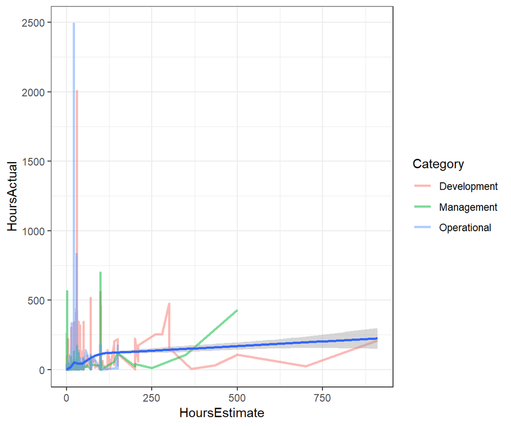

### Análise

Observando o gráfico acima, é possível inferir que as atividades operacionais possuem uma maior diferença entre a quantidade de horas necessárias para concluir a tarefa, e a quantidade de horas inicialmente estimada. É verificável também que todas as categorias de tarefas possuem uma cauda maior a direita. Além disso, é possível observar que há uma correlação positiva não-linear.

## Equipes com mais desenvolvedores produzem estimativas com mais ou menos erro que equipes menores?

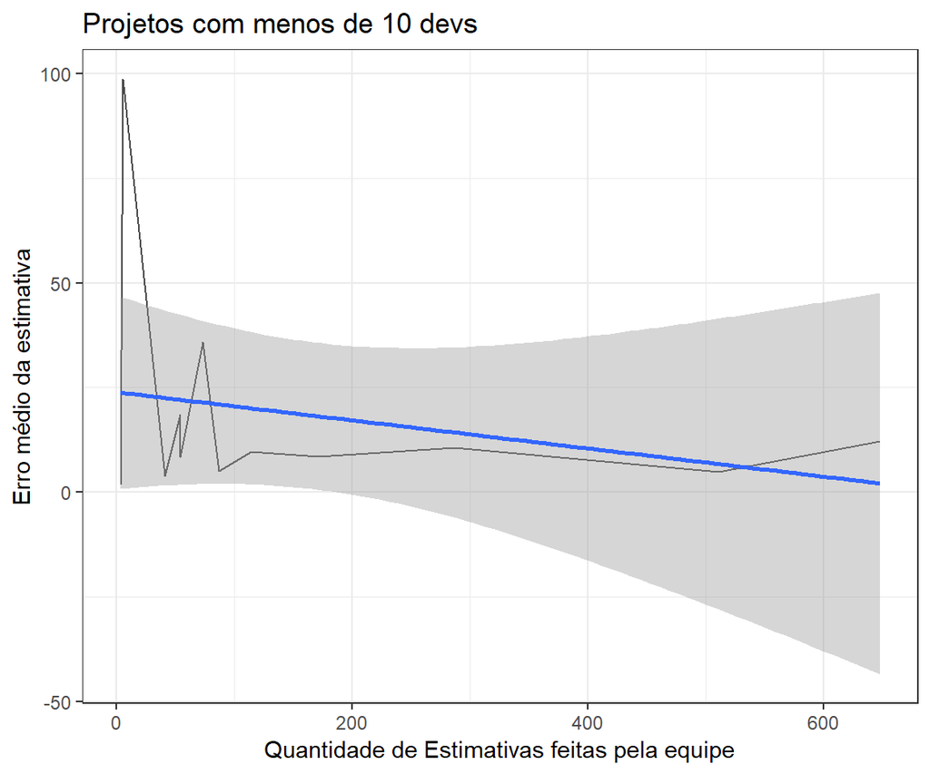

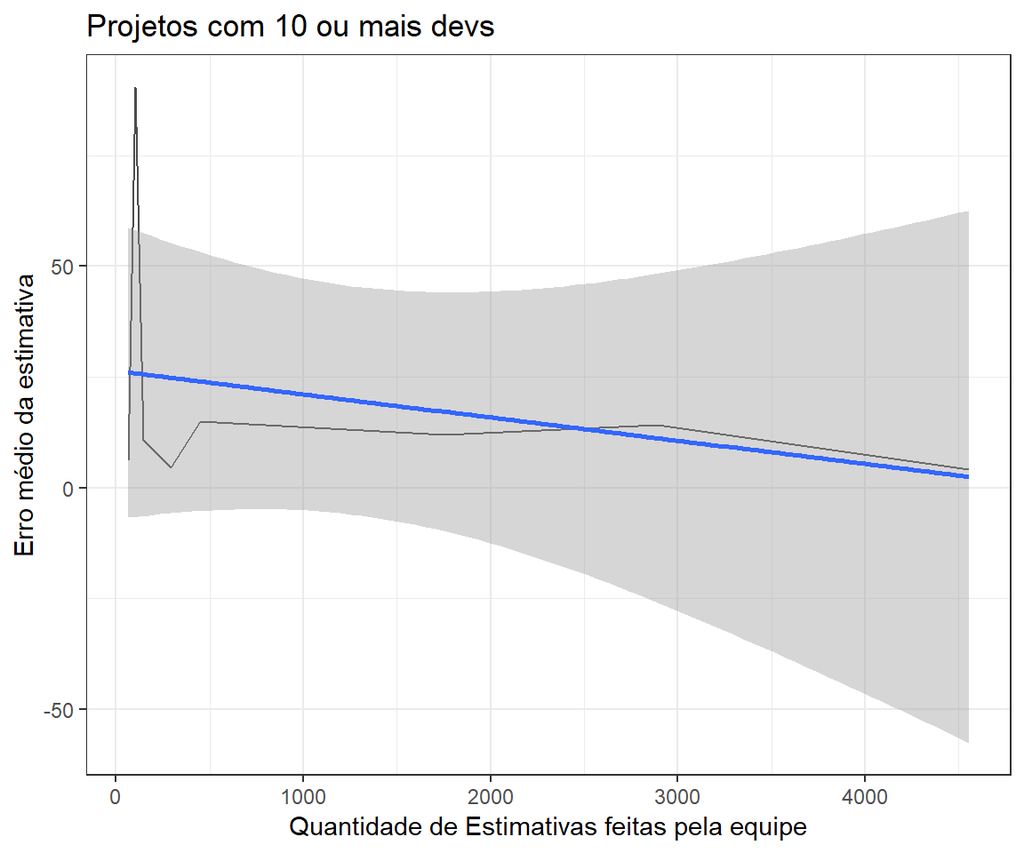